# FinalNotebook

## Problem definition

We want to predict the path of hurricanes with previous records. I decided to use this final exercise to deploy a time series forecast model (which would be my first). This will be treated as a problem of sequence prediction and faced with RNN. For this the I will closely follow the approach of Alemany et al 2019, where the data are mapped into a grid based on geographic coordinates and the prediction consist of knowing the next grid id where the hurricane is going to be based on previous sequences of grid id, the distance traveled and the bearing. My focus will be replicated and try to understand in more detailed manner possible the mentioned approach, of course making some changes under own considerations.

```python
import matplotlib.pyplot as plt
import pandas as pd
import numpy as np
import scipy
import re
from geopy.distance import great_circle as gcd
import math as Math
import time
from mpl_toolkits.basemap import Basemap
from sklearn.preprocessing import MinMaxScaler
from sklearn.preprocessing import StandardScaler
import keras
import tensorflow as tf
from keras.models import Sequential
from keras.layers.core import Dense, Dropout, Activation
from keras.layers.recurrent import LSTM
from keras.models import model_from_json
```

## Import and celaning data

The data will be loaded, for this case almost all original data values will be deleted under the consideration that most of the data recorded represent older phenomena, with no atmospherical variables captured like wind speed or pressure. We keep the hurriace ID, the dat and the grographic coordinates of the center. Name is also droped because it is only usefull for events after 1950.

```python
data = pd.read_csv('atlantic.csv')
```

Import and clean data

```python
data
```

|  | ID | Name | Date | Time | Event | Status | Latitude | Longitude | Maximum Wind | Minimum Pressure | ... | Low Wind SW | Low Wind NW | Moderate Wind NE | Moderate Wind SE | Moderate Wind SW | Moderate Wind NW | High Wind NE | High Wind SE | High Wind SW | High Wind NW |
| --- | --- | --- | --- | --- | --- | --- | --- | --- | --- | --- | --- | --- | --- | --- | --- | --- | --- | --- | --- | --- | --- |
| 0 | AL011851 | UNNAMED | 18510625 | 0 |  | HU | 28.0N | 94.8W | 80 | -999 | ... | -999 | -999 | -999 | -999 | -999 | -999 | -999 | -999 | -999 | -999 |
| 1 | AL011851 | UNNAMED | 18510625 | 600 |  | HU | 28.0N | 95.4W | 80 | -999 | ... | -999 | -999 | -999 | -999 | -999 | -999 | -999 | -999 | -999 | -999 |
| 2 | AL011851 | UNNAMED | 18510625 | 1200 |  | HU | 28.0N | 96.0W | 80 | -999 | ... | -999 | -999 | -999 | -999 | -999 | -999 | -999 | -999 | -999 | -999 |
| 3 | AL011851 | UNNAMED | 18510625 | 1800 |  | HU | 28.1N | 96.5W | 80 | -999 | ... | -999 | -999 | -999 | -999 | -999 | -999 | -999 | -999 | -999 | -999 |
| 4 | AL011851 | UNNAMED | 18510625 | 2100 | L | HU | 28.2N | 96.8W | 80 | -999 | ... | -999 | -999 | -999 | -999 | -999 | -999 | -999 | -999 | -999 | -999 |
| ... | ... | ... | ... | ... | ... | ... | ... | ... | ... | ... | ... | ... | ... | ... | ... | ... | ... | ... | ... | ... | ... |
| 49100 | AL122015 | KATE | 20151112 | 1200 |  | EX | 41.3N | 50.4W | 55 | 981 | ... | 180 | 120 | 120 | 120 | 60 | 0 | 0 | 0 | 0 | 0 |
| 49101 | AL122015 | KATE | 20151112 | 1800 |  | EX | 41.9N | 49.9W | 55 | 983 | ... | 180 | 120 | 120 | 120 | 60 | 0 | 0 | 0 | 0 | 0 |
| 49102 | AL122015 | KATE | 20151113 | 0 |  | EX | 41.5N | 49.2W | 50 | 985 | ... | 200 | 220 | 120 | 120 | 60 | 0 | 0 | 0 | 0 | 0 |
| 49103 | AL122015 | KATE | 20151113 | 600 |  | EX | 40.8N | 47.5W | 45 | 985 | ... | 180 | 220 | 0 | 0 | 0 | 0 | 0 | 0 | 0 | 0 |
| 49104 | AL122015 | KATE | 20151113 | 1200 |  | EX | 40.7N | 45.4W | 45 | 987 | ... | 150 | 220 | 0 | 0 | 0 | 0 | 0 | 0 | 0 | 0 |

49105 rows × 22 columns

The data is analyzed to eliminate variables with less than 50% valid data, undesrantung -999 and UNNAMED as missing values. Following this approach, most of the variables are eliminated conserving only the ID, geographic coordinates and maximum wind velocity. To exemplifi the value frecuency of Name and MAximum pressure is shown.

```python
data['Minimum Pressure'].value_counts(normalize=True)*100
```

```
-999     62.455962
 1005     1.798188
 1008     1.722839
 1006     1.645454
 1009     1.629162
           ...
 902      0.002036
 899      0.002036
 889      0.002036
 888      0.002036
 907      0.002036
Name: Minimum Pressure, Length: 130, dtype: float64
```

```python
data['Name'].value_counts(normalize=True)*100
```

```
            UNNAMED    54.094288
            FRANCES     0.645555
             ARLENE     0.576316
             BERTHA     0.545769
             DENNIS     0.519295
                         ...
              SHARY     0.018328
              TAMMY     0.018328
            SIXTEEN     0.016292
            FERNAND     0.014255
             AMELIA     0.012219
Name: Name, Length: 288, dtype: float64
```

```python
data=data.drop(['Minimum Pressure','Event','Status','Name','Low Wind NE','Low Wind SE','Low Wind SW','Low Wind NW','Moderate Wind NE','Moderate Wind SE','Moderate Wind SW','Moderate Wind NW','High Wind SW','High Wind NE','High Wind SE','High Wind NW'],axis=1)
```

We manipulate the data so we can acces to records based on an index created with ID key as basis. Then we count the total number of hurricanes, and obtain a total of 1814 different events recorded.

```python
keys = list(enumerate(pd.unique(data['ID'])))
total_hurricane_count = len(pd.unique(data['ID']))
print("There are "+str(total_hurricane_count)+" hurricanes in the database")
y = np.zeros((total_hurricane_count))
for x in range(0,total_hurricane_count):
    y[x] = len(pd.DataFrame(data[data['ID'] == keys[x][1]], columns = data.keys()).reset_index(drop = True))
hurricane_amount = pd.DataFrame(y)
```

```
There are 1814 hurricanes in the database
```

```python
hurricane_amount.describe()
```

|  | 0 |
| --- | --- |
| count | 1814.000000 |
| mean | 27.070011 |
| std | 16.983268 |
| min | 1.000000 |
| 25% | 14.000000 |
| 50% | 23.000000 |
| 75% | 37.000000 |
| max | 133.000000 |

```python
minObs= (hurricane_amount>20)
keysMinObs=[]
for  i in minObs.index:
    if minObs.loc[i][0]:
        keysMinObs.append(keys[i][1])
data = data[data['ID'].isin(keysMinObs)]
keys = list(enumerate(pd.unique(data['ID'])))
```

```
1039
```

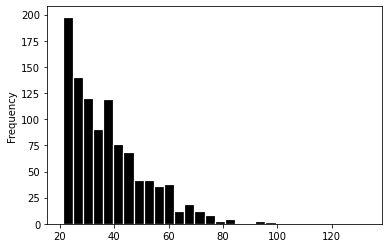

```python
total_hurricane_count = len(pd.unique(data['ID']))

print(total_hurricane_count)

y = np.zeros((total_hurricane_count))
for x in range(0,total_hurricane_count):
    y[x] = len(pd.DataFrame(data[data['ID'] == keys[x][1]], columns = data.keys()).reset_index(drop = True))

hurricane_amount = pd.DataFrame(y)
hurricane_amount.describe()
dist = hurricane_amount.plot.hist(bins=30, edgecolor='white', histtype='barstacked', color='black', legend=None, linewidth=1.2)
plt.show()
```

# Feature Engineering

Distance traveled from the last observation and bearing or travel direction based on current and previous pount will be estimated from the orginal geographic coordinates. For this we trasform the coordinate format into numeric values according to its cuadrant location and from there calculate espherical distance and bearing.

```python
def Nostr(x):
    sp=re.split('(N|W|S|E)',x)
    if sp[1] == 'W' or sp[1] == 'S':
        num=float(sp[0])*-1
    else:
        num=float(sp[0])
    return num
data['Latitude'] = data['Latitude'].apply(Nostr)
data['Longitude'] = data['Longitude'].apply(Nostr)
```

```python
total_data_count = len(data)
y = np.zeros(total_hurricane_count)
data['distance'] = np.zeros(total_data_count)
data['bearing'] = np.zeros(total_data_count)

for x in range(0, total_hurricane_count):
    t = pd.DataFrame(data[data['ID'] == keys[x][1]], columns = data.keys()).reset_index(drop = False)
    dst = 0
    prev = (0,0)

    for p in zip(t['Latitude'], t['Longitude']):

        if prev == (0,0):
            prev = p
            continue
        data.at[t[(t['Latitude'] == p[0]) & (t['Longitude'] == p[1])]['index'].values[0],'distance']=gcd(prev,p).kilometers

        dLon = p[1] - prev[1];
        temp = float(p[0])
        y_x = Math.sin(dLon) * Math.cos(temp)

        x_x = Math.cos(p[1]) * Math.sin(temp) - Math.sin(p[1]) * Math.cos(temp) * Math.cos(dLon)
        brng = Math.degrees(Math.atan2(y_x, x_x))
        if (brng < 0):
            brng+= 360

        data.at[t[(t['Latitude'] == p[0]) & (t['Longitude'] == p[1])]['index'].values[0], 'bearing']= brng
        dst += gcd(prev,p).kilometers
        prev = p
    y[x] = dst

hurricane_distance = pd.DataFrame(y)
```

We now have a 1039 table that includes the vectorial behavior of hurricane movement. We can also tell that the behavior of distance traveled variable presents great variability. There are hurricanes that travel only 718 kilometers, the mean traveled distance is 4810 and some hurricanes traveled up to 13902 kilometers.

```python
data
```

|  | ID | Date | Time | Latitude | Longitude | Maximum Wind | distance | bearing |
| --- | --- | --- | --- | --- | --- | --- | --- | --- |
| 16 | AL041851 | 18510816 | 0 | 13.4 | -48.0 | 40 | 0.000000 | 0.000000 |
| 17 | AL041851 | 18510816 | 600 | 13.7 | -49.5 | 40 | 165.545433 | 326.268781 |
| 18 | AL041851 | 18510816 | 1200 | 14.0 | -51.0 | 50 | 165.342833 | 349.579563 |
| 19 | AL041851 | 18510816 | 1800 | 14.4 | -52.8 | 50 | 199.067179 | 161.573455 |
| 20 | AL041851 | 18510817 | 0 | 14.9 | -54.6 | 60 | 201.466132 | 121.516233 |
| ... | ... | ... | ... | ... | ... | ... | ... | ... |
| 49080 | AL112015 | 20151014 | 0 | 36.0 | -9.0 | 20 | 67.316208 | 359.140120 |
| 49081 | AL112015 | 20151014 | 600 | 35.5 | -8.7 | 20 | 61.838635 | 323.341560 |
| 49082 | AL112015 | 20151014 | 1200 | 35.1 | -8.4 | 20 | 52.148787 | 210.415062 |
| 49083 | AL112015 | 20151014 | 1800 | 35.0 | -8.0 | 15 | 38.071961 | 204.811894 |
| 49084 | AL112015 | 20151015 | 0 | 35.2 | -7.7 | 15 | 35.205672 | 195.594607 |

39255 rows × 8 columns

```python
hurricane_distance.describe()
```

|  | 0 |
| --- | --- |
| count | 1039.000000 |
| mean | 4810.571326 |
| std | 2367.998761 |
| min | 718.601374 |
| 25% | 3047.282880 |
| 50% | 4348.485268 |
| 75% | 6149.359920 |
| max | 13902.037275 |

In the following table, the ID of the top 6 hurricanes which travel the longest distance is presented along with the distance in kilometers and the number of observations. AS expected, hurricanes with higher number of observations are those which travel the most.

```python
print ('Top 6 Hurricanes with longer paths')
for x in hurricane_distance.nlargest(6, 0).index:
    print (keys[x][1], "-", hurricane_distance.loc[x][0], "kilemters -", hurricane_amount.loc[x][0], " ","number of observations")
```

```
Top 6 Hurricanes with longer paths
AL031899 - 13902.037275075161 kilemters - 133.0   number of observations
AL032000 - 13519.340617835665 kilemters - 87.0   number of observations
AL061966 - 13439.368335126639 kilemters - 69.0   number of observations
AL011900 - 12774.077723429358 kilemters - 81.0   number of observations
AL092004 - 12484.604805793771 kilemters - 94.0   number of observations
AL122011 - 12481.711146561658 kilemters - 64.0   number of observations
```

The positive correlation between distance and number observations can be best illustrated in the following scatter plot, and by calculating Pearsons correlation coefficient, which is 77%, confirming a strong positive correlation.

```
[[1.         0.77093697]
 [0.77093697 1.        ]]
```

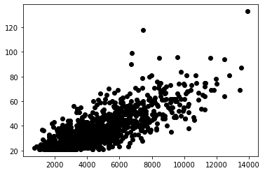

```python
print( np.corrcoef(hurricane_distance[0], hurricane_amount[0]) )

corr = plt.scatter(hurricane_distance[0], hurricane_amount[0], color='black')
```

For illustration the folloginf figures plot the path of the 5 longest and 5 shortest hurricanes. It is clear that the behavior depending on the size of the path is extremely different which might difficult the task of regression process.

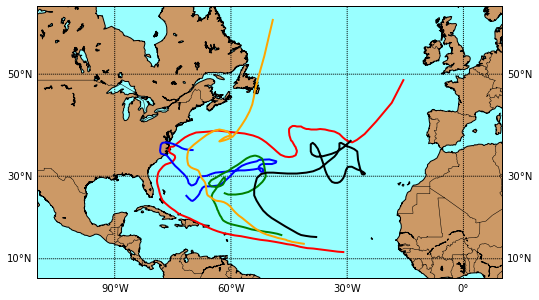

```python
n = 5

plt.figure(figsize=(10,5))
m = Basemap(llcrnrlon=-110.,llcrnrlat=5.,urcrnrlon=10.,urcrnrlat=60.,
            rsphere=(6378137.00,6356752.3142),
            resolution='l',
            projection='merc',
            lat_0=40.,lon_0=-20.,lat_ts=20.)
m.drawcoastlines()
m.drawcountries()
m.drawmapboundary(fill_color='#99ffff')
m.fillcontinents(color='#cc9966',lake_color='#99ffff')
m.drawparallels(np.arange(10,90,20),labels=[1,1,0,1])
m.drawmeridians(np.arange(-180,180,30),labels=[1,1,0,1])

colo=['red','blue','green','black','orange']
i=0
for x in hurricane_amount.nlargest(n,0).index:
    largest_hurr = data[data['ID'] == keys[x][1]]
    lat = largest_hurr['Latitude'].values
    long = largest_hurr['Longitude'].values
    xpt, ypt = m(long, lat)
    m.plot(xpt, ypt, linewidth=2, color=colo[i])
    i+=1
plt.show()
```

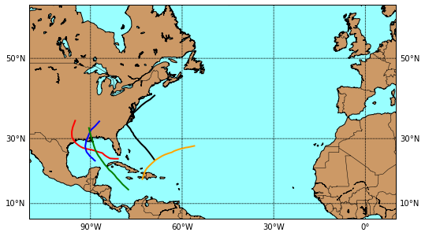

```python
n = 5

plt.figure(figsize=(10,5))
m = Basemap(llcrnrlon=-110.,llcrnrlat=5.,urcrnrlon=10.,urcrnrlat=60.,
            rsphere=(6378137.00,6356752.3142),
            resolution='l',
            projection='merc',
            lat_0=40.,lon_0=-20.,lat_ts=20.)
m.drawcoastlines()
m.drawcountries()
m.drawmapboundary(fill_color='#99ffff')
m.fillcontinents(color='#cc9966',lake_color='#99ffff')
m.drawparallels(np.arange(10,90,20),labels=[1,1,0,1])
m.drawmeridians(np.arange(-180,180,30),labels=[1,1,0,1])

colo=['red','blue','green','black','orange']
i=0
for x in hurricane_amount.nsmallest(n,0).index:
    largest_hurr = data[data['ID'] == keys[x][1]]
    lat = largest_hurr['Latitude'].values
    long = largest_hurr['Longitude'].values
    xpt, ypt = m(long, lat)
    m.plot(xpt, ypt, linewidth=2, color=colo[i])
    i+=1
plt.show()
```

The distribution of the final features is presented. The distribution of distance traveled in 6 hours interval is has a positive kurtosis will most of the values close to the mean, and is positively skewed for extreme values. The bearing distribution tells the more common directions where hurricanes travel, the strange thing is that 180 values, which represent south presents a peak, this might be biased for extreme observations.

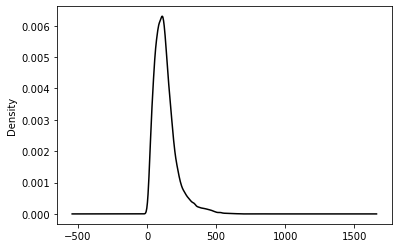

```python
dist = data[data['distance'] > 0]['distance']
ser = pd.Series(dist)
ser.plot(kind='kde', cmap='gray')
```

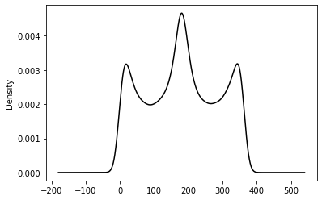

```python
direc = data[data['bearing'] > 0]
direc = (direc['bearing'])
ser = pd.Series(direc)
ser.plot(kind='kde', cmap='gray')
```

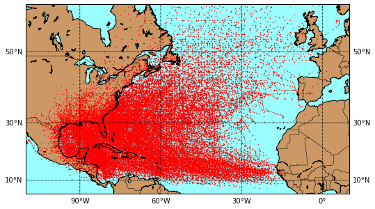

```python
plt.figure(figsize=(10,5))
m = Basemap(llcrnrlon=-110.,llcrnrlat=5.,urcrnrlon=10.,urcrnrlat=60.,
            rsphere=(6378137.00,6356752.3142),
            resolution='l',
            projection='merc',
            lat_0=40.,lon_0=-20.,lat_ts=20.)
m.drawcoastlines()
m.drawcountries()
m.drawmapboundary(fill_color='#99ffff')
m.fillcontinents(color='#cc9966',lake_color='#99ffff')
m.drawparallels(np.arange(10,90,20),labels=[1,1,0,1])
m.drawmeridians(np.arange(-180,180,30),labels=[1,1,0,1])

lat = data['Latitude'].values
long = data['Longitude'].values
xpt, ypt = m(long, lat)
m.scatter(xpt, ypt, .3, color='red')
plt.show()
```

Now, the label is created. The label will consist on a grid ID which is calculated based on coordinates. there will be a accuaricy lost as values are transformed into integers in several part of the calculation, this is algo a generalization step whre olny relatively big displacements are being captured.

```python
data['gridID'] = np.zeros(total_data_count)
lat_min = 7.2
long_min = -109.3
lat_interval = round(66 - 7.2)
long_interval = round(13.5 + 109.3)

data['gridID'] = np.floor(data['Latitude'] - 7.200)* long_interval  + np.floor(data['Longitude'] + 109.3)
data['gridID'] = round(data['gridID'])
```

```python
names = data['ID'].unique()
data.drop(['Date', 'Time', 'Latitude', 'Longitude'], axis = 1, inplace = True)
data.head()
```

|  | ID | Maximum Wind | distance | bearing | gridID |
| --- | --- | --- | --- | --- | --- |
| 16 | AL041851 | 40 | 0.000000 | 0.000000 | 799.0 |
| 17 | AL041851 | 40 | 165.545433 | 326.268781 | 797.0 |
| 18 | AL041851 | 50 | 165.342833 | 349.579563 | 796.0 |
| 19 | AL041851 | 50 | 199.067179 | 161.573455 | 917.0 |
| 20 | AL041851 | 60 | 201.466132 | 121.516233 | 915.0 |

```python
names
```

```
array(['AL041851', 'AL011852', 'AL041852', ..., 'AL062015', 'AL102015',
       'AL112015'], dtype=object)
```

```python
scalers = {}
gridScalers = {}
for name in names:
    scalers[name] = MinMaxScaler(feature_range=(0, 1))
    hurricane = data[data['ID'] == name]
    hurricane.drop('ID', axis = 1, inplace= True)

    hurricane = pd.DataFrame(scalers[name].fit_transform(hurricane), columns=['Maximum Wind','distance','bearing','gridID'])
    data.loc[data['ID'] == name, ['Maximum Wind','distance', 'bearing', 'gridID']] = hurricane.values
```

The following lines create a padded data structure which is then converted into a pad sequence object of the cross, used to manage and predict sequential observations.

```python
data_pad = []
for key in np.unique(data['ID']):
    data_pad += [data[ data.loc[:, 'ID'] == key].loc[:, ['Maximum Wind','distance', 'bearing', 'gridID']]]
```

```python
padded_data = keras.preprocessing.sequence.pad_sequences(data_pad, maxlen=60, dtype='float', padding='post', truncating='pre', value=0.0)
print(len(padded_data[0]))
print(len(padded_data))
padded_data
```

```
60
1039
```

```
array([[[3.33333333e-01, 0.00000000e+00, 0.00000000e+00, 1.21852153e-03],
        [3.33333333e-01, 4.45292032e-01, 6.05519716e-02, 8.12347685e-04],
        [3.33333333e-01, 3.98119661e-01, 5.70225160e-02, 4.06173842e-04],
        ...,
        [0.00000000e+00, 0.00000000e+00, 0.00000000e+00, 0.00000000e+00],
        [0.00000000e+00, 0.00000000e+00, 0.00000000e+00, 0.00000000e+00],
        [0.00000000e+00, 0.00000000e+00, 0.00000000e+00, 0.00000000e+00]],

       [[0.00000000e+00, 0.00000000e+00, 0.00000000e+00, 7.93650794e-03],
        [0.00000000e+00, 2.84649530e-01, 4.42534039e-01, 6.61375661e-03],
        [1.42857143e-01, 2.05527817e-01, 4.35757391e-01, 6.61375661e-03],
        ...,
        [0.00000000e+00, 0.00000000e+00, 0.00000000e+00, 0.00000000e+00],
        [0.00000000e+00, 0.00000000e+00, 0.00000000e+00, 0.00000000e+00],
        [0.00000000e+00, 0.00000000e+00, 0.00000000e+00, 0.00000000e+00]],

       [[0.00000000e+00, 0.00000000e+00, 0.00000000e+00, 0.00000000e+00],
        [0.00000000e+00, 6.11081810e-01, 3.67786230e-01, 4.55893254e-02],
        [0.00000000e+00, 5.81227832e-01, 1.89498076e-01, 4.52186805e-02],
        ...,
        [0.00000000e+00, 0.00000000e+00, 0.00000000e+00, 0.00000000e+00],
        [0.00000000e+00, 0.00000000e+00, 0.00000000e+00, 0.00000000e+00],
        [0.00000000e+00, 0.00000000e+00, 0.00000000e+00, 0.00000000e+00]],

       ...,

       [[0.00000000e+00, 0.00000000e+00, 0.00000000e+00, 3.44690517e-01],
        [0.00000000e+00, 1.00079070e-01, 5.01424950e-01, 3.44690517e-01],
        [0.00000000e+00, 1.33050103e-01, 5.01270684e-01, 3.45258376e-01],
        ...,
        [0.00000000e+00, 0.00000000e+00, 0.00000000e+00, 0.00000000e+00],
        [0.00000000e+00, 0.00000000e+00, 0.00000000e+00, 0.00000000e+00],
        [0.00000000e+00, 0.00000000e+00, 0.00000000e+00, 0.00000000e+00]],

       [[4.00000000e-01, 0.00000000e+00, 0.00000000e+00, 6.91808597e-01],
        [4.00000000e-01, 5.81923475e-01, 7.56319799e-01, 6.90997567e-01],
        [4.00000000e-01, 6.00322425e-01, 8.28346716e-01, 6.90186537e-01],
        ...,
        [0.00000000e+00, 0.00000000e+00, 0.00000000e+00, 0.00000000e+00],
        [0.00000000e+00, 0.00000000e+00, 0.00000000e+00, 0.00000000e+00],
        [0.00000000e+00, 0.00000000e+00, 0.00000000e+00, 0.00000000e+00]],

       [[1.66666667e-01, 0.00000000e+00, 0.00000000e+00, 4.24092409e-01],
        [5.00000000e-01, 2.70432545e-01, 5.83997261e-01, 6.27062706e-01],
        [6.66666667e-01, 3.34688951e-01, 5.73023215e-01, 6.25412541e-01],
        ...,
        [0.00000000e+00, 0.00000000e+00, 0.00000000e+00, 0.00000000e+00],
        [0.00000000e+00, 0.00000000e+00, 0.00000000e+00, 0.00000000e+00],
        [0.00000000e+00, 0.00000000e+00, 0.00000000e+00, 0.00000000e+00]]])
```

The padded data is reshaped in an arry wccounting for the 4 features defined.

```python
temp_flat = padded_data.reshape(60*1039,4)
temp_flat
```

```
array([[3.33333333e-01, 0.00000000e+00, 0.00000000e+00, 1.21852153e-03],
       [3.33333333e-01, 4.45292032e-01, 6.05519716e-02, 8.12347685e-04],
       [3.33333333e-01, 3.98119661e-01, 5.70225160e-02, 4.06173842e-04],
       ...,
       [0.00000000e+00, 0.00000000e+00, 0.00000000e+00, 0.00000000e+00],
       [0.00000000e+00, 0.00000000e+00, 0.00000000e+00, 0.00000000e+00],
       [0.00000000e+00, 0.00000000e+00, 0.00000000e+00, 0.00000000e+00]])
```

Now the model architecture is defined. As described by the designers: five total layers were employed. An input layer, three hidden vector state layers , and an output layer. The input layer takes in a data tuple. A data tuple is a sequence of features. The output layer contains an LSTM building unit along with the dropout value, a dense layer, and the final activation layer.

```python
def load_data(stock, seq_len, amount_of_features):
    sequence_length = seq_len + 1
    result = []

    for index in range(len(stock) - sequence_length):
        seq = stock[index: index + sequence_length]
        result.append(seq)

    result = np.array(result)
    row = len(result) * 0.9
    train = result[:int(row), :]
    x_train = train[:, :-1]
    y_train = train[:, -1][:,-1]
    x_test = result[int(row):, :-1]
    y_test = result[int(row):, -1][:,-1]

    x_train = np.reshape(x_train, (x_train.shape[0], x_train.shape[1], amount_of_features))
    x_test = np.reshape(x_test, (x_test.shape[0], x_test.shape[1], amount_of_features))

    return [x_train, y_train, x_test, y_test]
def build_model(layers):
    model = Sequential()

    for x in range(0,3):
        model.add(LSTM(units=layers[1], input_shape=(None, layers[0]), return_sequences=True))
        model.add(Dropout(0.1))

    model.add(LSTM(layers[2], return_sequences=False))
    model.add(Dropout(0.1))

    model.add(Dense(units=layers[2]))
    model.add(Activation("tanh"))

    start = time.time()
    opt = tf.keras.optimizers.SGD(learning_rate=1)
    model.compile(loss="mse", optimizer=opt,metrics=['accuracy'])
    print("Compilation Time : ", time.time() - start)
    return model
```

Data is devided into train a test sets

```python
seq_len = 10
feature_count = 4
X_train, y_train, X_test, y_test = load_data(temp_flat[::-1], seq_len, feature_count)
print("X_train", X_train.shape)
print("y_train", y_train.shape)
print("X_test", X_test.shape)
print("y_test", y_test.shape)
```

```
X_train (56096, 10, 4)
y_train (56096,)
X_test (6233, 10, 4)
y_test (6233,)
```

Model is compiled

```python
model = build_model([feature_count, seq_len, 1])
```

```
Compilation Time :  0.8611505031585693
```

```python
model.fit(X_train, y_train, batch_size=512, epochs=100, validation_split=0.1, verbose=1)
```

```
<keras.callbacks.History at 0x1bb9efd3b20>
```

```python
trainScore = model.evaluate(X_train, y_train, verbose=0)
print('Train Score: %.4f MSE (%.4f RMSE)' % (trainScore[0], Math.sqrt(trainScore[0])))

testScore = model.evaluate(X_test, y_test, verbose=0)
print('Test Score: %.4f MSE (%.4f RMSE)' % (testScore[0], Math.sqrt(testScore[0])))
```

```
Train Score: 0.0173 MSE (0.1314 RMSE)
Test Score: 0.0174 MSE (0.1318 RMSE)
```

The model is saved and imported to make some predictions over test data.

```python
model_json = model.to_json()
with open("model.json", "w") as json_file:
    json_file.write(model_json)

model.save_weights("model.h5")
print("Saved Model to Disk")
```

```
Saved Model to Disk
```

```python
# Load json and create model
json_file = open('model.json', 'r')
loaded_model_json = json_file.read()
json_file.close()
loaded_model = model_from_json(loaded_model_json)

# Load weights into new model
loaded_model.load_weights("model.h5")
print("Loaded Model from Disk")
model = loaded_model
```

```
WARNING:tensorflow:Layer lstm will not use cuDNN kernels since it doesn't meet the criteria. It will use a generic GPU kernel as fallback when running on GPU.
WARNING:tensorflow:Layer lstm_1 will not use cuDNN kernels since it doesn't meet the criteria. It will use a generic GPU kernel as fallback when running on GPU.
WARNING:tensorflow:Layer lstm_2 will not use cuDNN kernels since it doesn't meet the criteria. It will use a generic GPU kernel as fallback when running on GPU.
WARNING:tensorflow:Layer lstm_3 will not use cuDNN kernels since it doesn't meet the criteria. It will use a generic GPU kernel as fallback when running on GPU.
Loaded Model from Disk
```

```python
pred = model.predict(X_test)
```

In this graph the real and predicted grid is compared. Overall, the fit is appropriate, except in the critical zones where grid values are low or high. As this value are normalized ones, the values near 0 and 1 present the bigger error. By zooming a little (blue line graph) it is clear that small errors also exist in every location but the trend maintains, extreme values of grid ID present the bigger shifts.

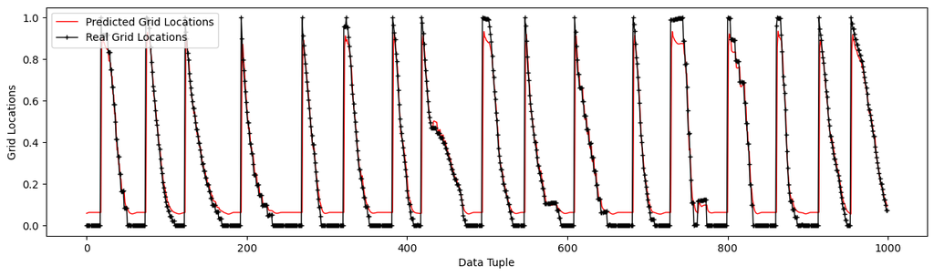

```python
plt.figure(figsize=(15, 4), dpi=100)
plt.plot(pred[:1000],
         linewidth=1,
         color='red',
         label='Predicted Grid Locations')
plt.plot(y_test[:1000],
         linewidth=1,
         color='black',
         marker='+',
         markersize=4,
         label='Real Grid Locations')
plt.xlabel('Data Tuple')
plt.ylabel('Grid Locations')

plt.legend(loc='upper left')
plt.show()
```

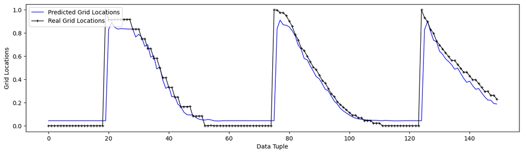

```python
plt.figure(figsize=(15, 4), dpi=100)
plt.plot(pred[:150],
         linewidth=1,
         color='blue',
         label='Predicted Grid Locations')
plt.plot(y_test[:150],
         linewidth=1,
         color='black',
         marker='+',
         markersize=4,
         label='Real Grid Locations')
plt.xlabel('Data Tuple')
plt.ylabel('Grid Locations')

plt.legend(loc='upper left')
plt.show()
```

Alemany, S., Beltran, J., Perez, A., & Ganzfried, S. (2019, July). Predicting hurricane trajectories using a recurrent neural network. In Proceedings of the AAAI Conference on Artificial Intelligence (Vol. 33, No. 01, pp. 468-475).